# Final Project 2025

## Project Title: Bank Marketing Classification Project

The objective of this teamwork is to implement a step-by-step classification analysis using Python's machine learning, data analysis, manipulation, and visualization libraries such as Scikit-Learn, Pandas, NumPy, and Matplotlib.

The entire project has been divided into three steps, which include data preprocessing and visualization, training the ML model, and model tuning and validation. The project must be completed by its deadline and submitted separately by each member of the groups to the corresponding assignment on our Itslearning platform.

The team size is 3-5 members.

The evaluation of the teamwork will occur by presenting the analysis and results in the presence of the instructor. Please use the provided Jupyter Notebook to document the aims of your project, describe the dataset, document your data analysis process, and evaluate the results. Make the analysis self-descriptive by adding Markdown comments and using descriptive variable names.

The efforts of individual team members will also be evaluated in the process.

### **Project Description:**

In this machine learning project, students will tackle a classification task that has real-world applications in marketing and financial institutions. The project focuses on predicting whether a client will subscribe to a term deposit in a bank, based on a set of features obtained through marketing campaigns. This project offers a hands-on opportunity to apply various data preprocessing techniques, build and evaluate classification models, and make informed decisions based on the results.

### **Project Goal:**

The primary goal of this project is to develop an accurate classification model that can assist the bank's marketing team in identifying potential clients who are more likely to subscribe to term deposits. By achieving this goal, the bank can optimize its marketing efforts, reduce costs, and improve the overall efficiency of its campaigns.

### **Potential Real-World Applications:**

Understanding the outcome of this classification task has several practical applications:

**1. Marketing Strategy Optimization:** The bank can use the predictive model to prioritize potential clients who are more likely to subscribe. This allows them to tailor marketing strategies and allocate resources more effectively, leading to higher conversion rates and reduced marketing expenses.

**2. Resource Allocation:** The model's predictions can help the bank allocate resources, such as marketing personnel and budget, to regions or customer segments that are more likely to yield positive results.

**3. Customer Relationship Management:** By identifying potential subscribers, the bank can personalize communication and services to meet the specific needs and preferences of clients, enhancing customer satisfaction and loyalty.

**4. Risk Assessment:** The model can assist in assessing the risk associated with marketing campaigns. By identifying clients less likely to subscribe, the bank can avoid aggressive marketing approaches that could lead to negative customer experiences.

### **Project Significance:**

This project mirrors real-world challenges faced by marketing teams in financial institutions. By successfully completing this project, students will not only gain technical skills in machine learning but also learn how to apply their knowledge to solve practical business problems. They will understand the importance of data-driven decision-making and how classification models can have a significant impact on marketing and resource allocation strategies.

### **Project Outcome:**

At the end of this project, students will have developed and evaluated a classification model capable of predicting term deposit subscriptions. They will be able to justify their model selection and discuss its potential applications in marketing and financial institutions.

Through this project, students will develop critical skills that are highly relevant in the data science and machine learning industry, as well as a deep understanding of the broader implications of their work.

### **Deadlines of submissions:**

Thursday 24 April 2025 at 09.00

### Project Submission and Presentation:

Please book a time for an evaluation event on Friday, April 25, 2025, as soon as the time slots are published. Note: The 15-minute time slots will be made available later on Itslearning. The groups will present their work during this evaluation event.

### **To pass this work, you must:** 1. Participate in using Python and some of its data analysis libraries. 2. Be active during the project. 3. Achieve a minimum of 0.5 grade units from the tasks marked with ** in each step. This equates to earning at least 1.5 units from the ** marked tasks across all steps. ### Project Evaluation In Itslearning and this notebook, it is graded from 0 to 29 points, considering both the teacher's assessment and the peer assessment provided by the rest of the project team.

#### Note: Please do not change the lines related to the grades in the code cells.

```python
## Enter your group name and your full names ##
group_name = 'Group 31'
members = 'Viktor Trilar, Zoi Theofilakou, Oleksandr Yakovlev'
grade = 0
```

### **Step 1: Data Visualization and Preprocessing** (8 points)

**Data Loading**: ** Start by loading the Bank Marketing Dataset (UCI) into your preferred data analysis environment (e.g., Python with libraries like Pandas and Matplotlib). (1 point)

**Data Exploration:** Perform initial exploratory data analysis (EDA) to understand the dataset's structure, summary statistics, and data types. (1 point)

**Data Splitting**: ** Split the preprocessed data into training and testing sets (e.g., 80% for training and 20% for testing). (1 point)

**Handling Missing Values:** Identify and handle missing values appropriately (e.g., impute missing values or drop rows/columns with missing data). (1 point)

**Encoding Categorical Features:** Convert categorical variables into numerical format using techniques like one-hot encoding or label encoding. (1 point)

**Data Scaling:** Normalize/standardize numerical features to ensure they have the same scale. (1 point)

**Data Visualization:** Create visualizations (e.g., histograms, box plots, and correlation matrices) to gain insights into the data distribution and relationships between features. (2 points)

```python
# Import required libraries
import pandas as pd
import numpy as np
import matplotlib.pyplot as plt
from sklearn.model_selection import train_test_split
from sklearn.preprocessing import StandardScaler
import seaborn as sns
```

```python
# Load the dataset
data_bank = pd.read_csv('data/bank-additional-full.csv', sep=';')

# Explore the data:
# 1. Display the first few rows
print(data_bank.head())
```

```
   age        job  marital    education  default housing loan    contact  \
0   56  housemaid  married     basic.4y       no      no   no  telephone
1   57   services  married  high.school  unknown      no   no  telephone
2   37   services  married  high.school       no     yes   no  telephone
3   40     admin.  married     basic.6y       no      no   no  telephone
4   56   services  married  high.school       no      no  yes  telephone

  month day_of_week  ...  campaign  pdays  previous     poutcome emp.var.rate  \
0   may         mon  ...         1    999         0  nonexistent          1.1
1   may         mon  ...         1    999         0  nonexistent          1.1
2   may         mon  ...         1    999         0  nonexistent          1.1
3   may         mon  ...         1    999         0  nonexistent          1.1
4   may         mon  ...         1    999         0  nonexistent          1.1

   cons.price.idx  cons.conf.idx  euribor3m  nr.employed   y
0          93.994          -36.4      4.857       5191.0  no
1          93.994          -36.4      4.857       5191.0  no
2          93.994          -36.4      4.857       5191.0  no
3          93.994          -36.4      4.857       5191.0  no
4          93.994          -36.4      4.857       5191.0  no

[5 rows x 21 columns]
```

```python
# 2. Get data type information
data_bank.info()
```

```
<class 'pandas.core.frame.DataFrame'>
RangeIndex: 41188 entries, 0 to 41187
Data columns (total 21 columns):
 #   Column          Non-Null Count  Dtype
---  ------          --------------  -----
 0   age             41188 non-null  int64
 1   job             41188 non-null  object
 2   marital         41188 non-null  object
 3   education       41188 non-null  object
 4   default         41188 non-null  object
 5   housing         41188 non-null  object
 6   loan            41188 non-null  object
 7   contact         41188 non-null  object
 8   month           41188 non-null  object
 9   day_of_week     41188 non-null  object
 10  duration        41188 non-null  int64
 11  campaign        41188 non-null  int64
 12  pdays           41188 non-null  int64
 13  previous        41188 non-null  int64
 14  poutcome        41188 non-null  object
 15  emp.var.rate    41188 non-null  float64
 16  cons.price.idx  41188 non-null  float64
 17  cons.conf.idx   41188 non-null  float64
 18  euribor3m       41188 non-null  float64
 19  nr.employed     41188 non-null  float64
 20  y               41188 non-null  object
dtypes: float64(5), int64(5), object(11)
memory usage: 6.6+ MB
```

```python
# 3. Get summary statistics
data_bank.describe(include='all')
```

|  | age | job | marital | education | default | housing | loan | contact | month | day_of_week | ... | campaign | pdays | previous | poutcome | emp.var.rate | cons.price.idx | cons.conf.idx | euribor3m | nr.employed | y |
| --- | --- | --- | --- | --- | --- | --- | --- | --- | --- | --- | --- | --- | --- | --- | --- | --- | --- | --- | --- | --- | --- |
| count | 41188.00000 | 41188 | 41188 | 41188 | 41188 | 41188 | 41188 | 41188 | 41188 | 41188 | ... | 41188.000000 | 41188.000000 | 41188.000000 | 41188 | 41188.000000 | 41188.000000 | 41188.000000 | 41188.000000 | 41188.000000 | 41188 |
| unique | NaN | 12 | 4 | 8 | 3 | 3 | 3 | 2 | 10 | 5 | ... | NaN | NaN | NaN | 3 | NaN | NaN | NaN | NaN | NaN | 2 |
| top | NaN | admin. | married | university.degree | no | yes | no | cellular | may | thu | ... | NaN | NaN | NaN | nonexistent | NaN | NaN | NaN | NaN | NaN | no |
| freq | NaN | 10422 | 24928 | 12168 | 32588 | 21576 | 33950 | 26144 | 13769 | 8623 | ... | NaN | NaN | NaN | 35563 | NaN | NaN | NaN | NaN | NaN | 36548 |
| mean | 40.02406 | NaN | NaN | NaN | NaN | NaN | NaN | NaN | NaN | NaN | ... | 2.567593 | 962.475454 | 0.172963 | NaN | 0.081886 | 93.575664 | -40.502600 | 3.621291 | 5167.035911 | NaN |
| std | 10.42125 | NaN | NaN | NaN | NaN | NaN | NaN | NaN | NaN | NaN | ... | 2.770014 | 186.910907 | 0.494901 | NaN | 1.570960 | 0.578840 | 4.628198 | 1.734447 | 72.251528 | NaN |
| min | 17.00000 | NaN | NaN | NaN | NaN | NaN | NaN | NaN | NaN | NaN | ... | 1.000000 | 0.000000 | 0.000000 | NaN | -3.400000 | 92.201000 | -50.800000 | 0.634000 | 4963.600000 | NaN |
| 25% | 32.00000 | NaN | NaN | NaN | NaN | NaN | NaN | NaN | NaN | NaN | ... | 1.000000 | 999.000000 | 0.000000 | NaN | -1.800000 | 93.075000 | -42.700000 | 1.344000 | 5099.100000 | NaN |
| 50% | 38.00000 | NaN | NaN | NaN | NaN | NaN | NaN | NaN | NaN | NaN | ... | 2.000000 | 999.000000 | 0.000000 | NaN | 1.100000 | 93.749000 | -41.800000 | 4.857000 | 5191.000000 | NaN |
| 75% | 47.00000 | NaN | NaN | NaN | NaN | NaN | NaN | NaN | NaN | NaN | ... | 3.000000 | 999.000000 | 0.000000 | NaN | 1.400000 | 93.994000 | -36.400000 | 4.961000 | 5228.100000 | NaN |
| max | 98.00000 | NaN | NaN | NaN | NaN | NaN | NaN | NaN | NaN | NaN | ... | 56.000000 | 999.000000 | 7.000000 | NaN | 1.400000 | 94.767000 | -26.900000 | 5.045000 | 5228.100000 | NaN |

11 rows × 21 columns

```python
# Check for missing values
print(data_bank.isnull().sum())
```

```
age               0
job               0
marital           0
education         0
default           0
housing           0
loan              0
contact           0
month             0
day_of_week       0
duration          0
campaign          0
pdays             0
previous          0
poutcome          0
emp.var.rate      0
cons.price.idx    0
cons.conf.idx     0
euribor3m         0
nr.employed       0
y                 0
dtype: int64
```

No missing values found

```python
# Specify categorical columns
cat_cols = data_bank.select_dtypes(include=['object']).columns
print(cat_cols)
```

```
Index(['job', 'marital', 'education', 'default', 'housing', 'loan', 'contact',
       'month', 'day_of_week', 'poutcome', 'y'],
      dtype='object')
```

```python
# Count and show  'unknown' values
print("Number of 'unknown' values per categorical feature:\n")
for col in cat_cols:
    count = (data_bank[col] == 'unknown').sum()
    if count > 0:
        print(f"{col}: {count}")
```

```
Number of 'unknown' values per categorical feature:

job: 330
marital: 80
education: 1731
default: 8597
housing: 990
loan: 990
```

```python
# Separate target variable from features
X = data_bank.drop(columns=['y'])
y = data_bank['y']

# Split data into training and testing sets
X_train, X_test, y_train, y_test = train_test_split(X, y, test_size=0.2, random_state=42)

# Check the shape of the training and testing sets
print(f"Features training set shape: {X_train.shape}")
print(f"Features testing test shape: {X_test.shape}")
print(f"Target training set shape: {y_train.shape}")
print(f"Target testing set shape: {y_test.shape}")
```

```
Features training set shape: (32950, 20)
Features testing test shape: (8238, 20)
Target training set shape: (32950,)
Target testing set shape: (8238,)
```

```python
# Handle missing values (e.g., replace missing values with the mean of the column)
num_cols = X_train.select_dtypes(include=['int64','float64']).columns

X_train[num_cols] = X_train[num_cols].fillna(X_train[num_cols].mean())
X_test[num_cols] = X_test[num_cols].fillna(X_train[num_cols].mean())
```

### Step: Handling Missing Values

All numerical columns were identified in the training set using their data types. Missing values filled in `X_train` using mean of each numerical column. Same imputation applied to `X_test.

```python
# Encoding categorical features (e.g., one-hot encoding)
X_train_encoded = pd.get_dummies(X_train, drop_first = True)
X_test_encoded = pd.get_dummies(X_test, drop_first= True)

# Align the training and testing sets to ensure they have the same columns
X_test_encoded = X_test_encoded.reindex(columns= X_train_encoded.columns, fill_value=0)

# Check the shape of the encoded training and testing sets
print(f"Encoded features training set shape: {X_train_encoded.shape}")
print(f"Encoded features testing set shape: {X_test_encoded.shape}")
```

```
Encoded features training set shape: (32950, 53)
Encoded features testing set shape: (8238, 53)
```

### Step: Encoding Categorical Features

- One-hot encoding was applied using pd.get_dummies() from pandas.
- Encoding was applied separately to X_train and X_test.
- drop_first=True to avoid multicollinearity by removing the first category of each feature.
- reindex() on X_test to align its columns with X_train, filling any missing columns with 0.

```python
# Data Scaling (normalize numerical features)


# Identify numerical columns in the encoded data
num_cols_encoded = X_train_encoded.select_dtypes(include=['int64','float64']).columns

# Initialize the scaler
scaler=StandardScaler()

# Fit the scaler on the training data and transform both train and test datasets
X_train_encoded[num_cols] = scaler.fit_transform(X_train_encoded[num_cols_encoded])
X_test_encoded[num_cols] = scaler.transform(X_test_encoded[num_cols_encoded])

# Check the first few rows of the scaled training set
print("First few rows of the scaled numerical features in the training set:")
print(X_train_encoded[num_cols_encoded].head())
# Check the first few rows of the scaled testing set
print("First few rows of the scaled numerical features in the testing set:")
```

```
First few rows of the scaled numerical features in the training set:
            age  duration  campaign     pdays  previous  emp.var.rate  \
12556 -0.001669 -0.631114 -0.206242  0.194661 -0.350902      0.838794
35451 -0.864095 -0.546321  0.513676  0.194661 -0.350902     -1.199440
30592  1.819007 -0.943306  1.233593  0.194661  1.677559     -1.199440
17914  0.285806 -0.631114  0.873635  0.194661 -0.350902      0.838794
3315  -0.097494  0.332441 -0.206242  0.194661 -0.350902      0.647709

       cons.price.idx  cons.conf.idx  euribor3m  nr.employed
12556        0.589080      -0.472769   0.771354     0.843165
35451       -1.180760      -1.229916  -1.372028    -0.939748
30592       -1.180760      -1.229916  -1.308581    -0.939748
17914        0.589080      -0.472769   0.771930     0.843165
3315         0.720307       0.890097   0.713674     0.330405
First few rows of the scaled numerical features in the testing set:
```

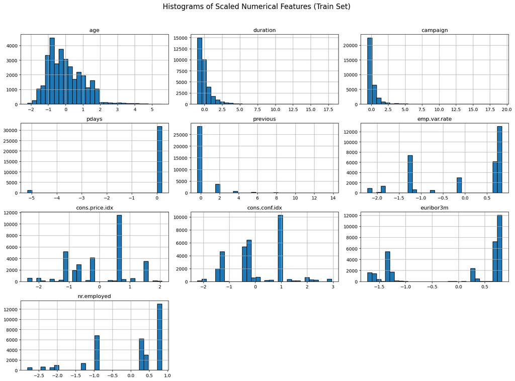

```python
# Data Visualization (e.g., histograms, box plots, and correlation matrices)

numeric_scaled = X_train_encoded[num_cols_encoded]

# Histogram of the scaled numerical features
plt.figure(figsize=(16,12))
numeric_scaled.hist(bins=30, edgecolor='black', layout=(4,3), figsize=(16,12))
plt.suptitle('Histograms of Scaled Numerical Features (Train Set)', fontsize=16)
plt.tight_layout(rect = [0, 0, 1, 0.96])
plt.show()
```

## Observations

- **age**: Right-skewed. Most clients are younger, while a few are much older (creating a tail on the right).
- **duration**: Right-skewed. Most calls are short; only a few lasted much longer.
- **campaign**: Right-skewed. Most clients were contacted 1–2 times; only a few were contacted 10+ times.
- **previous**: Right-skewed. The majority of clients had no or very few previous contacts.

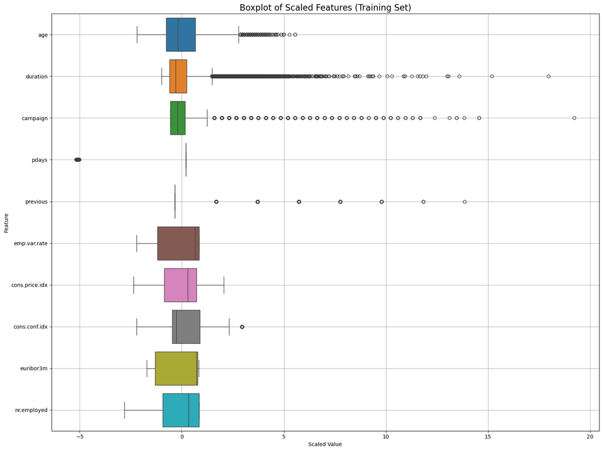

```python
#boxplot of the scaled features
plt.figure(figsize=(16,12))
sns.boxplot(data=numeric_scaled, orient='h')
plt.title('Boxplot of Scaled Features (Training Set)', fontsize=16)
plt.xlabel('Scaled Value')
plt.ylabel('Feature')
plt.grid(True)
plt.tight_layout()
plt.show()
```

### Box Plot Observations

- Most features centered at 0 and boxes appear centered.
- Outliers detected:

duration, campaign, and previous show many outliers, meaning that while most clients had short calls or few contacts, some clients were contacted excessively or had unusually long calls.

- Age distribution:

age appears balanced, but has a few outliers on the higher end, representing older clients.

- pdays & previous (no box):

The features have very little variation(same values), most clients were not contacted previously.

- Economic indicators (emp.var.rate, cons.price.idx, etc.):

These values are the same for many clients, which shows external economic conditions rather than personal behavior

Duration, campaign, age show more variation and behavior

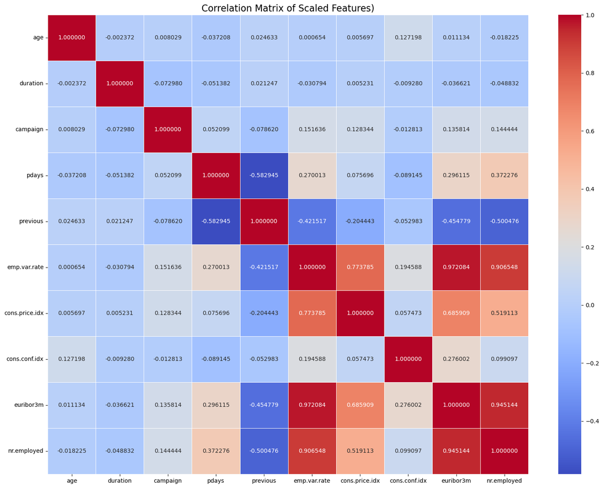

```python
# Correlation matrix
corr_matrix = numeric_scaled.corr()

# Plot heatmap of the correlation matrix
plt.figure(figsize =(16,12))
sns.heatmap(corr_matrix, annot =True, cmap='coolwarm', fmt = '2f', linewidths=0.5)
plt.title('Correlation Matrix of Scaled Features)', fontsize=16)
plt.tight_layout()
plt.show()
```

### Correlation Matrix: Observations

- **Strong positive correlations** between economic features:
  - euribor3m, nr.employed, and emp.var.rate are all highly correlated (> 0.9). It means they are similar and may confuse the model.
- **Negative correlation** between pdays and previous (-0.58)
  - Clients contacted a long time ago (pdays) had fewer recent interactions
- **Behavioral features** duration, campaign and age show weak or no correlation with others
  - These are useful for the model since they add independent information, meaning it is helpful for the model to learn more diverse and meaningful patterns.

```
Correlation of features with target variable (y):
y                                1.000000
duration                         0.402042
poutcome_success                 0.318767
previous                         0.230742
month_mar                        0.148693
month_oct                        0.143523
month_sep                        0.125958
job_student                      0.091886
job_retired                      0.088642
month_dec                        0.070444
cons.conf.idx                    0.055299
education_university.degree      0.053813
marital_single                   0.053211
age                              0.027631
education_unknown                0.016053
day_of_week_thu                  0.015912
job_unemployed                   0.014542
housing_yes                      0.010881
day_of_week_tue                  0.008119
education_illiterate             0.007441
day_of_week_wed                  0.004051
loan_unknown                     0.002981
housing_unknown                  0.002981
marital_unknown                  0.002550
education_professional.course    0.000415
job_management                  -0.000280
job_technician                  -0.001249
loan_yes                        -0.002052
default_yes                     -0.003396
job_unknown                     -0.003743
job_self-employed               -0.008180
month_jun                       -0.008262
month_aug                       -0.008560
job_housemaid                   -0.008696
education_high.school           -0.009604
month_nov                       -0.012660
job_entrepreneur                -0.016653
day_of_week_mon                 -0.019669
education_basic.6y              -0.024711
month_jul                       -0.029907
job_services                    -0.031471
marital_married                 -0.042574
education_basic.9y              -0.043711
campaign                        -0.069224
job_blue-collar                 -0.072718
default_unknown                 -0.099162
month_may                       -0.112121
cons.price.idx                  -0.134395
contact_telephone               -0.147177
poutcome_nonexistent            -0.192953
emp.var.rate                    -0.299619
euribor3m                       -0.309034
pdays                           -0.328757
nr.employed                     -0.356767
Name: y, dtype: float64
```

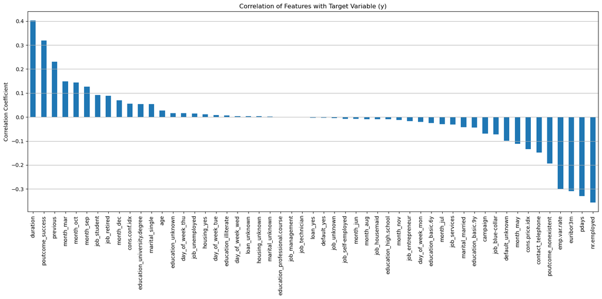

```python
# Map target variable to binary values
y_train_numeric = y_train.map({'yes': 1, 'no': 0})
y_test_numeric = y_test.map({'yes': 1, 'no': 0})

# Create temporary combined version to calculate correlation with target
X_train_temp = pd.concat([X_train_encoded, y_train_numeric], axis=1)

# Calculate correlation
corr_temp = X_train_temp.corr()
corr_target = corr_temp['y'].sort_values(ascending=False)

# Display correlations with the target
print("Correlation of features with target variable (y):")
print(corr_target)

# Plot barplot for correlation with target
plt.figure(figsize=(16, 8))
corr_target.drop('y').plot(kind='bar')
plt.title("Correlation of Features with Target Variable (y)")
plt.ylabel("Correlation Coefficient")
plt.grid(axis='y')
plt.tight_layout()
plt.show()
```

### Observations barplot target-key features:

*Positive correlations:*

- duration has the strongest positive correlation (~0.40) → longer calls are more likely to lead to a "yes".
- poutcome_success and previous contacts also increase the chances of a positive outcome.
- March, October, September are more successful than others.
- Jobs like students and retirees show slightly higher success rates.

*Negative correlations:*

- nr.employed, euribor3m, and pdays → lower chance of success when employment or interest rates are high, or when clients were contacted long ago.

*Summary*

Positive values mean higher chance of success. Negative values suggest lower chances. This plot helps us select the most useful features when building models.

```python
#points += 8
```

### **Step 2: Training Three Classification Models** (8 points)

**Model Selection:** Choose three classification algorithms: Logistic Regression, Decision Tree, and K-nearest neighborhood (KNN). (0.5 grade units)

**Model Training:** ** Train each of the selected models on the training dataset. (4 points)

**Model Evaluation:** Evaluate the performance of each model on the testing dataset using appropriate evaluation metrics (e.g., accuracy, precision, recall, F1-score, ROC-AUC). (4 points)

```python
# Step 2: Training Three Classification Models
from sklearn.linear_model import LogisticRegression
from sklearn.tree import DecisionTreeClassifier
from sklearn.neighbors import KNeighborsClassifier
from sklearn.metrics import accuracy_score, precision_score, recall_score, f1_score, roc_auc_score, confusion_matrix, roc_curve, auc
```

```python
# Selected models
log_model = LogisticRegression(max_iter=1000, random_state=42)
tree_model = DecisionTreeClassifier(random_state=42)
knn_model = KNeighborsClassifier(n_neighbors=5)

# Train models
log_model.fit(X_train_encoded, y_train_numeric)
tree_model.fit(X_train_encoded, y_train_numeric)
knn_model.fit(X_train_encoded, y_train_numeric)
```

```
KNeighborsClassifier()
```

```python
# Evaluation of models
y_pred_log = log_model.predict(X_test_encoded)
y_pred_tree = tree_model.predict(X_test_encoded)
y_pred_knn = knn_model.predict(X_test_encoded)

# Metrics for each model
y_prob_log = log_model.predict_proba(X_test_encoded)[:, 1]
y_prob_tree = tree_model.predict_proba(X_test_encoded)[:, 1]
y_prob_knn = knn_model.predict_proba(X_test_encoded)[:, 1]
```

```python
# Printing the models evaluating metrics
def evaluate_model(y_test, y_pred, y_prob, model_name):
    print(f"===== {model_name} =====")
    print("Accuracy:", accuracy_score(y_test_numeric, y_pred))
    print("Precision:", precision_score(y_test_numeric, y_pred))
    print("Recall:", recall_score(y_test_numeric, y_pred))
    print("F1-Score:", f1_score(y_test_numeric, y_pred))
    print("ROC-AUC:", roc_auc_score(y_test_numeric, y_prob))
    print("Confusion Matrix:")
    print(confusion_matrix(y_test_numeric, y_pred))
    print("\n")
```

```python
evaluate_model(y_test_numeric, y_pred_log, y_prob_log, "Logistic Regression")
evaluate_model(y_test_numeric, y_pred_tree, y_prob_tree, "Decision Tree")
evaluate_model(y_test_numeric, y_pred_knn, y_prob_knn, "K-Nearest Neighbors")
```

```
===== Logistic Regression =====
Accuracy: 0.911143481427531
Precision: 0.669449081803005
Recall: 0.4288770053475936
F1-Score: 0.5228161668839635
ROC-AUC: 0.9348834007854072
Confusion Matrix:
[[7105  198]
 [ 534  401]]


===== Decision Tree =====
Accuracy: 0.8862588006797767
Precision: 0.4989754098360656
Recall: 0.520855614973262
F1-Score: 0.5096807953950812
ROC-AUC: 0.7269484154559587
Confusion Matrix:
[[6814  489]
 [ 448  487]]


===== K-Nearest Neighbors =====
Accuracy: 0.9030104394270454
Precision: 0.5947075208913649
Recall: 0.4566844919786096
F1-Score: 0.5166364186327889
ROC-AUC: 0.8759400026800209
Confusion Matrix:
[[7012  291]
 [ 508  427]]
```

#### Interpretetion of results:

**Logistic Regression**

- Highest accuracy, precision, F1-score, and ROC-AUC.
- Slightly lower recall than Decision Tree, but overall balanced.
- The most stable and reliable model here.

**Decision Tree**

- Best recall (ability to correctly identify actual subscribers).
- Lower precision (more false positives) and ROC-AUC.
- Good if prefer recall more (manager prefer to contact more people even at the cost of false positives).

**KNN**

- Performance between Logistic Regression and Decision Tree.
- Good balance but not outperforming Logistic Regression.

```python
#points += 8
```

### **Step 3: Model Tuning and Validation (Including ROC Curve Analysis and Model Selection Rationale)** (8 points)

**Hyperparameter Tuning**: ** Perform hyperparameter tuning for each model to optimize their performance. You can use techniques like grid search or random search. (1 point)

**Cross-Validation:** Implement k-fold cross-validation to ensure that the models generalize well to new data. (1 point)

**ROC Curve Analysis:** For each model, calculate the ROC curve and the corresponding area under the ROC curve (AUC-ROC) as a performance metric. Plot the ROC curves for visual comparison. (1 point)

**Threshold Selection:** Determine the optimal threshold for classification by considering the ROC curve and choosing the point that balances sensitivity and specificity based on the problem's context (1 point)

**Final Model Selection:** Select the best-performing model based on the AUC-ROC, cross-validation results, and other relevant evaluation metrics (e.g., accuracy, precision, recall, F1-score). (1 point)

**Model Testing:** ** Evaluate the selected model on a separate validation dataset (if available) or the testing dataset from Step 1. (1 point)

**Rationale for Model Selection:** In this section, provide a written explanation for why you chose the final model for testing. Discuss the key factors that influenced your decision, such as the AUC-ROC performance, cross-validation results, and any specific characteristics of the problem. Explain how the selected model aligns with the goals of the project and its potential practical applications. This step encourages critical thinking and demonstrates your understanding of the machine learning workflow. (2 points)

```python
from sklearn.metrics import roc_curve
from sklearn.metrics import accuracy_score, precision_score, recall_score, f1_score, confusion_matrix
from sklearn.model_selection import cross_val_score, KFold
from sklearn.model_selection import GridSearchCV

# K-fold cross-validation
kf = KFold(n_splits=5, shuffle=True, random_state=42)

# Cross-validation for each model (assuming log_model, tree_model, knn_model are already defined)
cross_val_log = cross_val_score(log_model, X_train_encoded, y_train_numeric, cv=kf, scoring='roc_auc')
cross_val_tree = cross_val_score(tree_model, X_train_encoded, y_train_numeric, cv=kf, scoring='roc_auc')
cross_val_knn = cross_val_score(knn_model, X_train_encoded, y_train_numeric, cv=kf, scoring='roc_auc')

# Hyperparameter tuning for Decision Tree
param_grid_tree = {
    'max_depth': [None, 5, 10, 15],
    'min_samples_split': [2, 5, 10],
    'min_samples_leaf': [1, 2, 4]
}
grid_tree = GridSearchCV(tree_model, param_grid_tree, cv=5, scoring='roc_auc', n_jobs=-1)
grid_tree.fit(X_train_encoded, y_train_numeric)
best_tree_model = grid_tree.best_estimator_
best_tree_model.fit(X_train_encoded, y_train_numeric)
y_pred_best_tree = best_tree_model.predict(X_test_encoded)
y_prob_best_tree = best_tree_model.predict_proba(X_test_encoded)[:, 1]

# Hyperparameter tuning for Logistic Regression
param_grid_log = {
    'C': [0.01, 0.1, 1, 10, 100],
    'penalty': ['l2'],
    'solver': ['lbfgs', 'saga']
}
grid_log = GridSearchCV(log_model, param_grid_log, cv=5, scoring='roc_auc', n_jobs=-1)
grid_log.fit(X_train_encoded, y_train_numeric)
best_log_model = grid_log.best_estimator_
best_log_model.fit(X_train_encoded, y_train_numeric)
y_pred_best_log = best_log_model.predict(X_test_encoded)
y_prob_best_log = best_log_model.predict_proba(X_test_encoded)[:, 1]

# Hyperparameter tuning for K-Nearest Neighbors
param_grid_knn = {
    'n_neighbors': [3, 5, 7, 9],
    'weights': ['uniform', 'distance'],
    'metric': ['euclidean', 'manhattan']
}
grid_knn = GridSearchCV(knn_model, param_grid_knn, cv=5, scoring='roc_auc', n_jobs=-1)
grid_knn.fit(X_train_encoded, y_train_numeric)
best_knn_model = grid_knn.best_estimator_
best_knn_model.fit(X_train_encoded, y_train_numeric)
y_pred_best_knn = best_knn_model.predict(X_test_encoded)
y_prob_best_knn = best_knn_model.predict_proba(X_test_encoded)[:, 1]

# Dictionary for cleaner printing of results
grid_dict = {
    'Tuned Logistic Regression': grid_log,
    'Tuned Decision Tree': grid_tree,
    'Tuned K-Nearest Neighbors': grid_knn
}

# Function to evaluate the best model
def evaluate_best_model(y_test, y_pred, y_prob, model_name):
    print(f"===== {model_name} =====")
    print("Best Parameters:", grid_dict[model_name].best_params_)
    print("Accuracy:", accuracy_score(y_test_numeric, y_pred))
    print("Precision:", precision_score(y_test_numeric, y_pred))
    print("Recall:", recall_score(y_test_numeric, y_pred))
    print("F1-Score:", f1_score(y_test_numeric, y_pred))
    print("K Fold Cross-Validation Score:", cross_val_score(grid_dict[model_name].best_estimator_, X_train_encoded, y_train_numeric, cv=kf, scoring='roc_auc').mean())
    print("Confusion Matrix:")
    print(confusion_matrix(y_test_numeric, y_pred))
    print("\n")

# Evaluate the models
evaluate_best_model(y_test_numeric, y_pred_best_log, y_prob_best_log, "Tuned Logistic Regression")
evaluate_best_model(y_test_numeric, y_pred_best_tree, y_prob_best_tree, "Tuned Decision Tree")
evaluate_best_model(y_test_numeric, y_pred_best_knn, y_prob_best_knn, "Tuned K-Nearest Neighbors")
```

```
===== Tuned Logistic Regression =====
Best Parameters: {'C': 1, 'penalty': 'l2', 'solver': 'lbfgs'}
Accuracy: 0.911143481427531
Precision: 0.669449081803005
Recall: 0.4288770053475936
F1-Score: 0.5228161668839635
K Fold Cross-Validation Score: 0.9348511498796231
Confusion Matrix:
[[7105  198]
 [ 534  401]]


===== Tuned Decision Tree =====
Best Parameters: {'max_depth': 5, 'min_samples_leaf': 4, 'min_samples_split': 2}
Accuracy: 0.9150279193979121
Precision: 0.6508344030808729
Recall: 0.5422459893048128
F1-Score: 0.5915985997666278
K Fold Cross-Validation Score: 0.92529682689667
Confusion Matrix:
[[7031  272]
 [ 428  507]]


===== Tuned K-Nearest Neighbors =====
Best Parameters: {'metric': 'euclidean', 'n_neighbors': 9, 'weights': 'distance'}
Accuracy: 0.9045884923525127
Precision: 0.6130500758725341
Recall: 0.4320855614973262
F1-Score: 0.506900878293601
K Fold Cross-Validation Score: 0.8992676168687602
Confusion Matrix:
[[7048  255]
 [ 531  404]]
```

```python
# Perform ROC curve analysis and calculate AUC-ROC for each model

# AUC-ROC curve for Logistic Regression
fpr_log, tpr_log, thresholds = roc_curve(y_test_numeric, y_prob_best_log,)
roc_auc_log = auc(fpr_log, tpr_log)

# AUC-ROC curve for Decision Tree
fpr_tree, tpr_tree, thresholds_tree = roc_curve(y_test_numeric, y_prob_best_tree)
roc_auc_tree = auc(fpr_tree, tpr_tree)

# AUC-ROC curve for K-Nearest Neighbors
fpr_knn, tpr_knn, thresholds_knn = roc_curve(y_test_numeric, y_prob_best_knn)
roc_auc_knn = auc(fpr_knn, tpr_knn)

# Print AUC-ROC values
def print_roc_auc(model_name, roc_auc):
    print(f"ROC-AUC for {model_name}: {roc_auc}")

print_roc_auc("Tuned Logistic Regression", roc_auc_log)
print_roc_auc("Tuned Decision Tree", roc_auc_tree)
print_roc_auc("Tuned K-Nearest Neighbors", roc_auc_knn)
```

```
ROC-AUC for Tuned Logistic Regression: 0.9348834007854072
ROC-AUC for Tuned Decision Tree: 0.9221399747082183
ROC-AUC for Tuned K-Nearest Neighbors: 0.9042006032243727
```

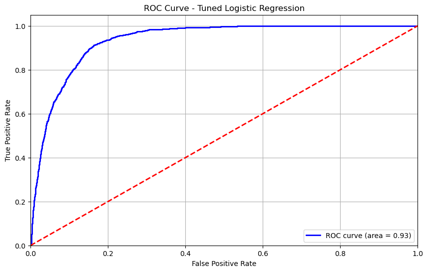

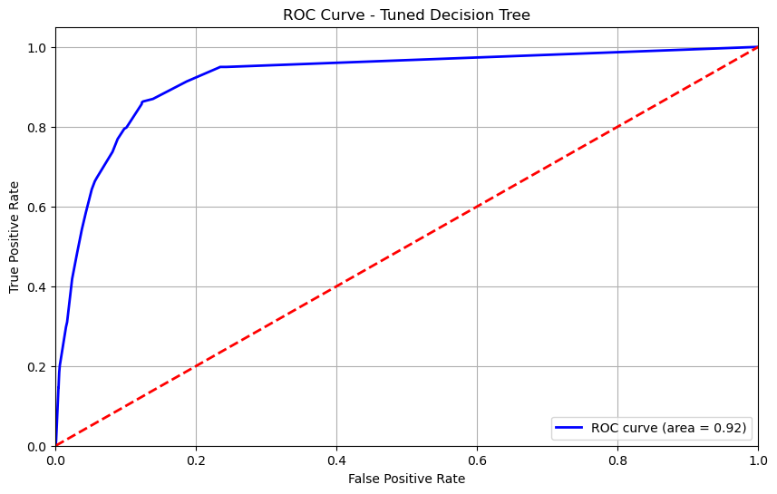

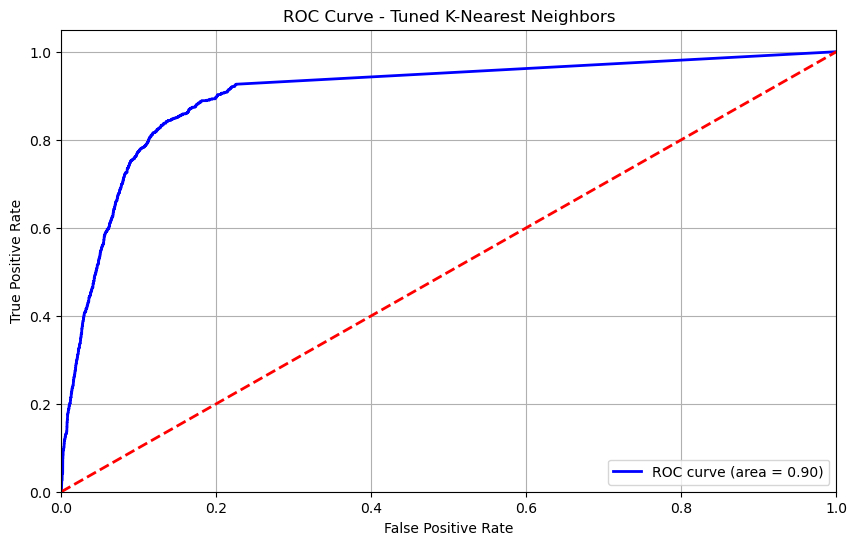

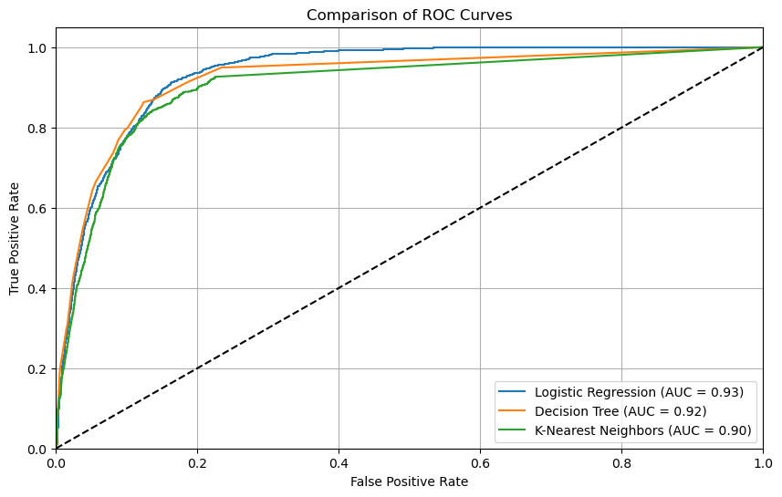

```python
# Visualize ROC curves

def plot_roc_curve(fpr, tpr, roc_auc, model_name):
    plt.figure(figsize=(10, 6))
    plt.plot(fpr, tpr, color='blue', lw=2, label=f'ROC curve (area = {roc_auc:.2f})')
    plt.plot([0, 1], [0, 1], color='red', lw=2, linestyle='--')
    plt.xlim([0.0, 1.0])
    plt.ylim([0.0, 1.05])
    plt.xlabel('False Positive Rate')
    plt.ylabel('True Positive Rate')
    plt.title(f'ROC Curve - {model_name}')
    plt.legend(loc='lower right')
    plt.grid()
    plt.show()

plot_roc_curve(fpr_log, tpr_log, roc_auc_log, "Tuned Logistic Regression")
plot_roc_curve(fpr_tree, tpr_tree, roc_auc_tree, "Tuned Decision Tree")
plot_roc_curve(fpr_knn, tpr_knn, roc_auc_knn, "Tuned K-Nearest Neighbors")

# Comparing all together
plt.figure(figsize=(10, 6))
plt.plot(fpr_log, tpr_log, label=f'Logistic Regression (AUC = {roc_auc_log:.2f})')
plt.plot(fpr_tree, tpr_tree, label=f'Decision Tree (AUC = {roc_auc_tree:.2f})')
plt.plot(fpr_knn, tpr_knn, label=f'K-Nearest Neighbors (AUC = {roc_auc_knn:.2f})')
plt.plot([0, 1], [0, 1], 'k--')
plt.xlim([0.0, 1.0])
plt.ylim([0.0, 1.05])
plt.xlabel('False Positive Rate')
plt.ylabel('True Positive Rate')
plt.title('Comparison of ROC Curves')
plt.legend(loc='lower right')
plt.grid()
plt.show()
```

```python
# Threshold Selection (You can manually select a threshold based on ROC analysis)

# Threshold selection for Logistic Regression
optimal_log = np.argmax(tpr_log - fpr_log)
optimal_threshold = thresholds[optimal_log]
print(f"Optimal Threshold: {optimal_threshold:.2f}")

# Threshold selection for Decision Tree
optimal_tree = np.argmax(tpr_tree - fpr_tree)
optimal_threshold_tree = thresholds_tree[optimal_tree]
print(f"Optimal Threshold (Decision Tree): {optimal_threshold_tree:.2f}")

# Threshold selection for K-Nearest Neighbors
optimal_knn = np.argmax(tpr_knn - fpr_knn)
optimal_threshold_knn = thresholds_knn[optimal_knn]
print(f"Optimal Threshold (K-Nearest Neighbors): {optimal_threshold_knn:.2f}")

# Apply optimal thresholds to models
y_pred_log_optimal = (y_prob_best_log >= optimal_threshold).astype(int)
y_pred_tree_optimal = (y_prob_best_tree >= optimal_threshold_tree).astype(int)
y_pred_knn_optimal = (y_prob_best_knn >= optimal_threshold_knn).astype(int)

# Evaluate new optimal models
def evaluate_optimal_model(y_test, y_pred, y_prob, model_name):
    print(f"===== {model_name} (Optimal Threshold) =====")
    print("Accuracy:", accuracy_score(y_test_numeric, y_pred))
    print("Precision:", precision_score(y_test_numeric, y_pred))
    print("Recall:", recall_score(y_test_numeric, y_pred))
    print("F1-Score:", f1_score(y_test_numeric, y_pred))
    print("ROC-AUC:", roc_auc_score(y_test_numeric, y_prob))
    print("K-Fold Cross-Validation Score:", cross_val_score(grid_dict[model_name].best_estimator_, X_train_encoded, y_train_numeric, cv=kf, scoring='roc_auc').mean())
    print("Confusion Matrix:")
    print(confusion_matrix(y_test_numeric, y_pred))
    print("\n")

evaluate_optimal_model(y_test_numeric, y_pred_log_optimal, y_prob_best_log, "Tuned Logistic Regression")
evaluate_optimal_model(y_test_numeric, y_pred_tree_optimal, y_prob_best_tree, "Tuned Decision Tree")
evaluate_optimal_model(y_test_numeric, y_pred_knn_optimal, y_prob_best_knn, "Tuned K-Nearest Neighbors")
```

```
Optimal Threshold: 0.10
Optimal Threshold (Decision Tree): 0.15
Optimal Threshold (K-Nearest Neighbors): 0.11
===== Tuned Logistic Regression (Optimal Threshold) =====
Accuracy: 0.8453508133042
Precision: 0.41711491442542786
Recall: 0.9122994652406418
F1-Score: 0.5724832214765101
ROC-AUC: 0.9348834007854072
K-Fold Cross-Validation Score: 0.9348511498796231
Confusion Matrix:
[[6111 1192]
 [  82  853]]


===== Tuned Decision Tree (Optimal Threshold) =====
Accuracy: 0.8742413207089099
Precision: 0.47055393586005834
Recall: 0.8631016042780749
F1-Score: 0.609056603773585
ROC-AUC: 0.9221399747082183
K-Fold Cross-Validation Score: 0.92529682689667
Confusion Matrix:
[[6395  908]
 [ 128  807]]


===== Tuned K-Nearest Neighbors (Optimal Threshold) =====
Accuracy: 0.8277494537509105
Precision: 0.3871268656716418
Recall: 0.8877005347593583
F1-Score: 0.5391360831438778
ROC-AUC: 0.9042006032243727
K-Fold Cross-Validation Score: 0.8992676168687602
Confusion Matrix:
[[5989 1314]
 [ 105  830]]
```

Overall the Decision Tree model has the best balance of the metrics after applying the thresholds.

```python
# Final Model Selection (Select the best-performing model based on AUC-ROC)

print("Final Model Selection based on AUC-ROC: Logistic Regression")
print("Best Parameters:", grid_log.best_params_)
print("ROC-AUC:", roc_auc_log)
```

```
Final Model Selection based on AUC-ROC: Logistic Regression
Best Parameters: {'C': 1, 'penalty': 'l2', 'solver': 'lbfgs'}
ROC-AUC: 0.9348834007854072
```

Based on AUC-ROC the best perfoming model is the Logistic Regression model. However if we are looking at the models with optimal thresholds applied, the Decision Tree model offers the best overall balance for precision and recall.

```python
# Model Testing (Evaluate the selected model on the testing dataset)

def evaluate_on_test(y_test, y_pred, y_prob, model, model_name, X_train, y_train, kf):
    print(f"===== {model_name} =====")
    print("Accuracy:", accuracy_score(y_test, y_pred))
    print("Precision:", precision_score(y_test, y_pred))
    print("Recall:", recall_score(y_test, y_pred))
    print("F1-Score:", f1_score(y_test, y_pred))
    print("ROC-AUC:", roc_auc_score(y_test, y_prob))
    print("K-Fold CV:", cross_val_score(model, X_train, y_train, cv=kf, scoring='roc_auc').mean())
    print("Confusion Matrix:")
    print(confusion_matrix(y_test, y_pred))
    print("\n")



y_pred_test_log = best_log_model.predict(X_test_encoded)
y_prob_test_log = best_log_model.predict_proba(X_test_encoded)[:, 1]

evaluate_on_test(y_test_numeric, y_pred_test_log, y_prob_test_log, best_log_model, "Tuned Logistic Regression - On test set", X_train_encoded, y_train_numeric, kf)
evaluate_on_test(y_test_numeric, y_pred_log_optimal, y_prob_best_log, best_log_model, "Tuned Logistic Regression - (Optimal threshold) - On test set", X_train_encoded, y_train_numeric, kf)
```

```
===== Tuned Logistic Regression - On test set =====
Accuracy: 0.911143481427531
Precision: 0.669449081803005
Recall: 0.4288770053475936
F1-Score: 0.5228161668839635
ROC-AUC: 0.9348834007854072
K-Fold CV: 0.9348511498796231
Confusion Matrix:
[[7105  198]
 [ 534  401]]


===== Tuned Logistic Regression - (Optimal threshold) - On test set =====
Accuracy: 0.8453508133042
Precision: 0.41711491442542786
Recall: 0.9122994652406418
F1-Score: 0.5724832214765101
ROC-AUC: 0.9348834007854072
K-Fold CV: 0.9348511498796231
Confusion Matrix:
[[6111 1192]
 [  82  853]]
```

```python
# Rationale for Model Selection:
# In this section, provide a written explanation for why you chose the final model for testing. Discuss the key factors that influenced your decision, such as the AUC-ROC performance, cross-validation results, and any specific characteristics of the problem. Explain how the selected model aligns with the goals of the project and its potential practical applications. This step encourages critical thinking and demonstrates your understanding of the machine learning workflow.
```

The final selected model will be the Logistic Regression model with optimal thresholds applied.

The model was chosen based on the ROC score (93%) and high rate of recall (91%), the K-Fold score (93%) also assures the performance is consistent. While the model without optimal thresholds has higher precision (minimizing resources wasted), the model with optimal threshold has a much higher recall which would ensure targeting as many potential customers as possible.

This can be seen when comparing confusion matrices: Without optimal threshold, only 401 actual customers were correctly identified (true positives), while 534 were missed (false negatives). With optimal threshold, the model correctly identifies 853 customers and only misses 82, showing a massive improvement.

The trade off of resource waste vs gaining potential customers seems very much worth it in the bank telemarketing context, since the cost of a phone call or email is relatively low compared to the potential value of a new customer. Therefore maximizing recall and reaching more potential customers is more valuable than conserving costs through higher precision.

```python
#grade += 8
```

### Additional Challenges (Optional):

To make the project more challenging, you can introduce the following tasks and collect 5 extra points for the project:

1. Implement an ensemble method (e.g., Neural Network or Random Forest) and compare its performance with the individual models.
2. Deal with class imbalance in the target variable.
3. Explore feature engineering to create new features that might improve model performance.

```python
from sklearn.ensemble import RandomForestClassifier

rfc = RandomForestClassifier(random_state=42, class_weight='balanced')

# Hyperparameter tuning for RFC
param_grid_rfc = {
    'n_estimators': [50, 100, 200],
    'max_depth': [None, 5, 10, 15],
    'min_samples_split': [2, 5, 10],
    'min_samples_leaf': [1, 2, 4]
}
# Grid search for RFC
grid_rfc = GridSearchCV(rfc, param_grid_rfc, cv=5, scoring='roc_auc', n_jobs=-1)
grid_rfc.fit(X_train_encoded, y_train_numeric)
best_rfc_model = grid_rfc.best_estimator_
y_pred_best_rfc = best_rfc_model.predict(X_test_encoded)
y_prob_best_rfc = best_rfc_model.predict_proba(X_test_encoded)[:, 1]

# Add the tuned Random Forest model to the grid dictionary
grid_dict["Tuned Random Forest Classifier"] = grid_rfc

# Evaluate the best Random Forest model
evaluate_best_model(y_test_numeric, y_pred_best_rfc, y_prob_best_rfc, "Tuned Random Forest Classifier")
```

```
===== Tuned Random Forest Classifier =====
Best Parameters: {'max_depth': None, 'min_samples_leaf': 4, 'min_samples_split': 2, 'n_estimators': 200}
Accuracy: 0.8888079630978393
Precision: 0.5059635907093534
Recall: 0.8620320855614974
F1-Score: 0.6376582278481012
K Fold Cross-Validation Score: 0.9470374096874504
Confusion Matrix:
[[6516  787]
 [ 129  806]]
```

```python
from sklearn.metrics import precision_recall_curve

# Finding optimal threshold for RFC
precisions, recalls, thresholds_rfc = precision_recall_curve(y_test_numeric, y_prob_best_rfc)
f1_scores = 2 * (precisions * recalls) / (precisions + recalls)
optimal_rfc = np.argmax(f1_scores)
optimal_threshold_rfc = thresholds_rfc[optimal_rfc]
print(f"Optimal Threshold (Random Forest): {optimal_threshold_rfc:.2f}")

grid_dict["Tuned Random Forest Classifier"] = grid_rfc

# Apply optimal threshold to RFC
y_pred_rfc_optimal = (y_prob_best_rfc >= optimal_threshold_rfc).astype(int)
evaluate_optimal_model(y_test_numeric, y_pred_rfc_optimal, y_prob_best_rfc, "Tuned Random Forest Classifier")
```

```
Optimal Threshold (Random Forest): 0.58
===== Tuned Random Forest Classifier (Optimal Threshold) =====
Accuracy: 0.9017965525613013
Precision: 0.547085201793722
Recall: 0.7828877005347593
F1-Score: 0.644082710074791
ROC-AUC: 0.9463328014785515
K-Fold Cross-Validation Score: 0.9470374096874504
Confusion Matrix:
[[6697  606]
 [ 203  732]]
```

The Random Forest model beats out our optimized Logistic Regression in every metric except in recall. Overall the RF model is better balanced than the LR model, meaning that it is a good choice when we want to avoid resource waste while still having a good amount of gain in potential customers. If we want to be aggressive in gaining potential customers then we should choose the LR model. Ultimately the model choice comes down to what we want to prioritize.

```python
# Feature engineering (calls over 300 seconds are considered long calls which could be used to predict the target variable)

data_bank['long_call'] = (data_bank['duration'] > 300).astype(int)

# Create new sets train and test splits
X_train_long_call = X_train.copy()
X_test_long_call = X_test.copy()
X_train_long_call['long_call'] = (X_train_long_call['duration'] > 300).astype(int)
X_test_long_call['long_call'] = (X_test_long_call['duration'] > 300).astype(int)


# Re-encoding
X_train_long_call_encoded = pd.get_dummies(X_train_long_call, drop_first=True)
X_test_long_call_encoded = pd.get_dummies(X_test_long_call, drop_first=True)
X_test_long_call_encoded = X_test_long_call_encoded.reindex(columns=X_train_long_call_encoded.columns, fill_value=0)

# Re-scaling
X_train_long_call_encoded[num_cols] = scaler.fit_transform(X_train_long_call_encoded[num_cols_encoded])
X_test_long_call_encoded[num_cols] = scaler.transform(X_test_long_call_encoded[num_cols_encoded])

# Re-train the Logistic regression (Optimal threshold) model with the new feature
best_log_model_long_call = LogisticRegression(max_iter=1000, random_state=42)
best_log_model_long_call.fit(X_train_long_call_encoded, y_train_numeric)
y_pred_best_log_long_call = best_log_model_long_call.predict(X_test_long_call_encoded)
y_prob_best_log_long_call = best_log_model_long_call.predict_proba(X_test_long_call_encoded)[:, 1]

# Grid search for Logistic Regression with the new feature
param_grid_log_long_call = {
    'C': [0.01, 0.1, 1, 10, 100],
    'penalty': ['l2'],
    'solver': ['lbfgs', 'saga']
}
grid_log_long_call = GridSearchCV(best_log_model_long_call, param_grid_log_long_call, cv=5, scoring='roc_auc', n_jobs=-1)
grid_log_long_call.fit(X_train_long_call_encoded, y_train_numeric)
best_log_model_long_call = grid_log_long_call.best_estimator_
y_pred_best_log_long_call = best_log_model_long_call.predict(X_test_long_call_encoded)
y_prob_best_log_long_call = best_log_model_long_call.predict_proba(X_test_long_call_encoded)[:, 1]

# Optimal threshold for Logistic Regression with long call feature
optimal_log_long_call = np.argmax(tpr_log - fpr_log)
optimal_threshold_log_long_call = thresholds[optimal_log_long_call]

# Apply optimal threshold to Logistic Regression with long call feature
y_pred_log_long_call_optimal = (y_prob_best_log_long_call >= optimal_threshold_log_long_call).astype(int)

grid_dict["Tuned Logistic Regression with Long Call Feature"] = grid_log_long_call

# Printing the metrics for the previous LR model
evaluate_on_test(y_test_numeric, y_pred_log_optimal, y_prob_best_log, best_log_model, "Tuned Logistic Regression - (Optimal threshold) - On test set", X_train_encoded, y_train_numeric, kf)
# Evaluate the LR model with the new feature on test set
evaluate_on_test(y_test_numeric, y_pred_best_log_long_call, y_prob_best_log_long_call, best_log_model_long_call, "Tuned Logistic Regression with Long Call Feature", X_train_long_call_encoded, y_train_numeric, kf)


# Grid search for Random Forest with the new feature
grid_rfc_long_call = GridSearchCV(rfc, param_grid_rfc, cv=5, scoring='roc_auc', n_jobs=-1)
grid_rfc_long_call.fit(X_train_long_call_encoded, y_train_numeric)
best_rfc_model_long_call = grid_rfc_long_call.best_estimator_
y_pred_best_rfc_long_call = best_rfc_model_long_call.predict(X_test_long_call_encoded)
y_prob_best_rfc_long_call = best_rfc_model_long_call.predict_proba(X_test_long_call_encoded)[:, 1]

# Optimal threshold for Random Forest with long call feature
precisions_rfc_long_call, recalls_rfc_long_call, thresholds_rfc_long_call = precision_recall_curve(y_test_numeric, y_prob_best_rfc_long_call)
f1_scores_rfc_long_call = 2 * (precisions_rfc_long_call * recalls_rfc_long_call) / (precisions_rfc_long_call + recalls_rfc_long_call)
optimal_rfc_long_call = np.argmax(f1_scores_rfc_long_call)
optimal_threshold_rfc_long_call = thresholds_rfc_long_call[optimal_rfc_long_call]

# Apply optimal threshold to Random Forest with long call feature
y_pred_rfc_long_call_optimal = (y_prob_best_rfc_long_call >= optimal_threshold_rfc_long_call).astype(int)

grid_dict["Tuned Random Forest Classifier with Long Call Feature"] = grid_rfc_long_call

# Printing the metrics for the previous RFC model
evaluate_optimal_model(y_test_numeric, y_pred_rfc_optimal, y_prob_best_rfc, "Tuned Random Forest Classifier")
# Evaluate new RF model with long call feature on test set
evaluate_on_test(y_test_numeric, y_pred_best_rfc_long_call, y_prob_best_rfc_long_call, best_rfc_model_long_call, "Tuned Random Forest Classifier with Long Call Feature", X_train_long_call_encoded, y_train_numeric, kf)
```

```
===== Tuned Logistic Regression - (Optimal threshold) - On test set =====
Accuracy: 0.8453508133042
Precision: 0.41711491442542786
Recall: 0.9122994652406418
F1-Score: 0.5724832214765101
ROC-AUC: 0.9348834007854072
K-Fold CV: 0.9348511498796231
Confusion Matrix:
[[6111 1192]
 [  82  853]]


===== Tuned Logistic Regression with Long Call Feature =====
Accuracy: 0.9100509832483612
Precision: 0.659016393442623
Recall: 0.4299465240641711
F1-Score: 0.5203883495145631
ROC-AUC: 0.9344172528907246
K-Fold CV: 0.9336305855598013
Confusion Matrix:
[[7095  208]
 [ 533  402]]


===== Tuned Random Forest Classifier (Optimal Threshold) =====
Accuracy: 0.9017965525613013
Precision: 0.547085201793722
Recall: 0.7828877005347593
F1-Score: 0.644082710074791
ROC-AUC: 0.9463328014785515
K-Fold Cross-Validation Score: 0.9470374096874504
Confusion Matrix:
[[6697  606]
 [ 203  732]]


===== Tuned Random Forest Classifier with Long Call Feature =====
Accuracy: 0.887836853605244
Precision: 0.5034140285536933
Recall: 0.8673796791443851
F1-Score: 0.6370777690494894
ROC-AUC: 0.9474877000954117
K-Fold CV: 0.9470568015967846
Confusion Matrix:
[[6503  800]
 [ 124  811]]
```

```python
#grade += 5
```

## Peer evaluation (5 points)

Each team member can gain max 5 points based on peer review

- Peer review is done separately in ITS